# UNIT06B 機率分佈函數的操作

Tony Chuo, NSYSU

2022-04-05 22:36:57

**👨‍🏫 **KEY POINTS :****

🔑 Distribution: the connections among probability, probability density and probability density functions (PDF/CDF).

🔑 3 different types of variables. Each has a distinctive distribution form.

🔑 A same set of operations generally apply to all kinds of distribution.

🔑 Put distribution functions in use.

🔑 Define random variables by simulating random experiment

```r
pacman::p_load(dplyr, vcd, future.apply)
plan(multisession)
```

### 1. The 3 types of Variable/Distribution

There are 3 types of variables. Categorical variables are always discrete. Their distributions are represented by counts and barplots. Numerical variables are either Discrete (integers) or Continuous (real numbers). The former are visualized by barplots and the latter histograms. The distributions of both Numeric types may be precisely specified by mathematical formula named after PDF and CDF.

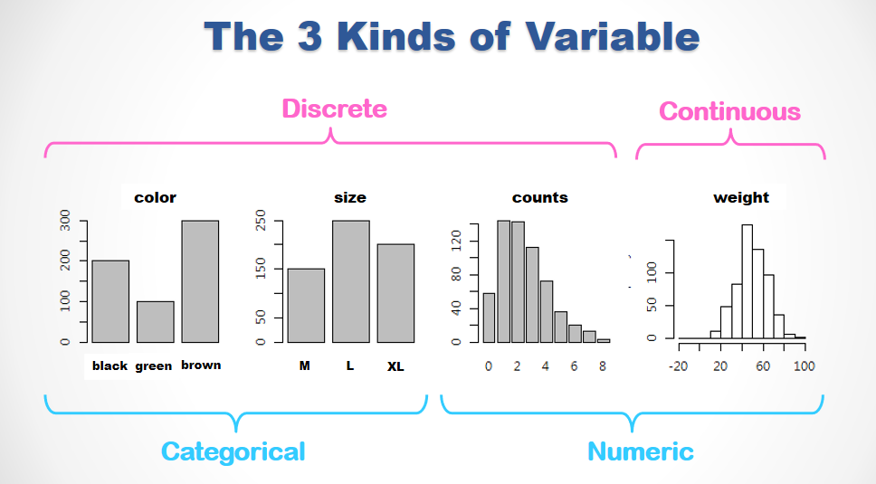

##### 1.1 Built-in Distribution Functions

Most of the commonly used distributions functions are built-in in R (See the online help of `distributions` for details.)

- beta : `dbeta()`
- binomial : `dbinom()`
- Cauchy : `dcauchy()`
- chi-squared : `dchisq()`
- exponential : `dexp()`
- F : `df()`
- gamma : `dgamma()`
- geometric : `dgeom
- hypergeometric : `dhyper()`
- log-normal : `dlnorm()`
- multinomial : `dmultinom()`
- negative binomial : `dnbinom()`
- normal : `dnorm()`
- Poisson : `dpois()`
- Student’s t : `dt()`
- uniform : `dunif()`
- Weibull : `dweibull()`

and there are more of them in various packages.

##### 1.2 The 4 Operations upon Distibutions

There are 4 common operations that generally apply to every distributions.

- `d<dist>(x, <args>)` : for probability density function (PDF)
- `p<dist>(q, <args>)` : for cumulative distribution function (CDF)
- `q<dist>(p, <args>)` : for quantile function, the reversed CDF
- `r<dist>(n, <args>)` : for random sampling

where `<dist>` specifies a specific distribution and represent the corresponding arguments. For examples

- `_norm(., mean, sd)` for `Normal[mean,sd]` and
- `_binom(., size, prob)` for `Binomial[size,prob]`.

These distribution operation function will be elaborated in the following sections.

### 2. Prob. Density Function (PDF) - `d<dist>`

For a continuous distribution such as `dnorm(x, mean, sd)` returns the probability density at `x` for `Normal[mean,sd]`.

For a discrete distribution such as `dbinom(x, size, prob)` returns the probability at `x` for `Binomial[size,prob]`.

Usually the `d` functions are used to plot PDF.

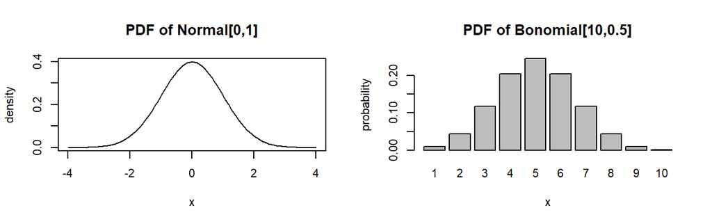

```r
par(mfrow=c(1,2), cex=0.7)
curve(dnorm(x), -4, 4,
      main="PDF of Normal[0,1]", ylab="density")
barplot(dbinom(1:10,10,0.5),names=1:10,
        main="PDF of Bonomial[10,0.5]", ylab="probability", xlab="x")
```

🦋 **DISCUSSION :**

Try to elaborate the difference between the continuous and discrete distributions in the following aspects …

🐞 the mathematical forms of PDF  
值域是連續值 or 離散值

🐞 the plotting codes  
連續 : curve ； 離散 : barplot

🐞 the label on the y-axis  
連續 : density ； 離散 : probability

🐞 What is **probability density**? How is it different from **probability** itself?  
probability density :  
必須有確定的有界區間為前提，面積就是事件在這個區間發生的概率  
(等於一段區間(事件的取值範圍)的概率除以該段區間的長度)  
連續型單點機率為0(沒有意義)

probability :  
常用來量化對於某些不確定命題的想法，是對隨機事件發生之可能性的度量  
離散型單點有機率(有意義)

🚴 **Exercise :**

👉 Acquire the prob. density of Standard Normal Dist. (`Normal[mu=0,sd=1]`) at `-3:3`

```r
dnorm(-3:3)
```

```
[1] 0.0044318 0.0539910 0.2419707 0.3989423 0.2419707 0.0539910 0.0044318
```

👉 Acquire and Plot the prob. densities of `Normal[mu=100,sd=20]` at `seq(50,120,10)`. Plot with `type='h',lwd=5,col='pink` and label the plot with the appropriate (適合的) `main`, `xlab`, `ylab` arguments in `plot()`.

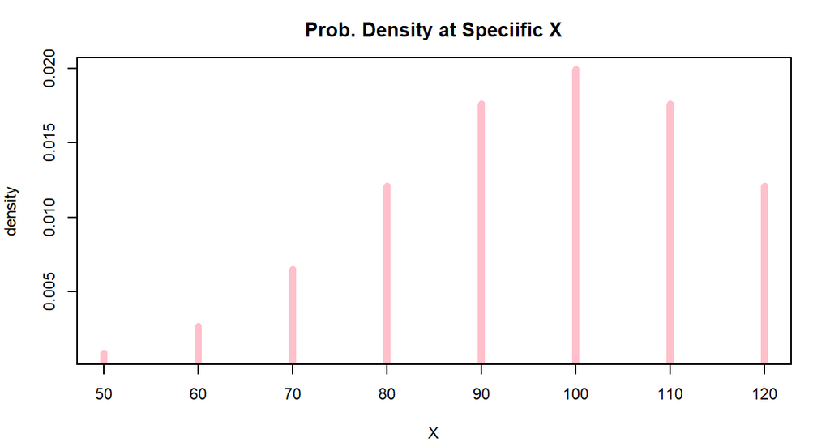

```r
par(mar=c(4,4,3,2), cex=0.7)

x = seq(50,120,10)
y = dnorm (x, mean=100, sd=20)

plot(x, y, type="h", lwd=5, col='pink',
     main="Prob. Density at Speciific X", ylab="density", xlab="X")
```

👉 Acquire the probabilities of `Binomial[n=10,p=1/6]` at `c(0,2,4,6,8,10)`

```r
dbinom(c(0,2,4,6,8,10),size = 10,prob = 1/6)
```

```
[1] 0.161505582890 0.290710049202 0.054265875851 0.002170635034 0.000018605443
[6] 0.000000016538
```

👉 Roll a fair dice 10 times, what is the probability of having exactly 2 one’s.

```r
dbinom(2, 10, 1/6)
```

```
[1] 0.29071
```

👉 Roll a fair dice 20 times, what is the probability of having less than 5 one’s.

```r
sum(dbinom(0:4, 20, 1/6)) # PDF
```

```
[1] 0.76875
```

```r
pbinom(4, 20, 1/6)  # CDF
```

```
[1] 0.76875
```

### 3. Cumulative Density Function (CDF) - `p<dist>`

For any continuous distributions, there is no probability at any given point. Therefore we usually define each event as a specific range of value. If we were to acquire the probability of such an event with PDF, we’d have to do calculus integration over the range. By integrating PDF from its left tail, CDF offers a easier way to acquire the probability over a range. For an example, the probability of $x \in [-1,2]$ in Standard Normal Dist. can be acquired by subtracting the CDF reading at the upper bound to that at the lower.

```r
pnorm(2) - pnorm(-1)
```

```
[1] 0.81859
```

🚴 **Exercise :**

👉 Acquire the prob. of Standard Normal Dist. in the interval `[-Inf, -3]`.

```r
pnorm(-3)
```

```
[1] 0.0013499
```

👉 Acquire the prob. of `Normal[mu=100,sd=50]` in the interval `[0, 50]`.

```r
pnorm(50,100,50) - pnorm(0,100,50)
```

```
[1] 0.13591
```

👉 If the distribution of the temperature at this season follows `Normal[mu=25,sd=10]` Celsius, what is the probability that tomorrow’s average temperature is higher than 30°C.

```r
1 - pnorm(30,25,10)
```

```
[1] 0.30854
```

👉 Flipping a fair coin 100 times, what is the probability to have less than 35 heads?

```r
pbinom(34,100,0.5)
```

```
[1] 0.00089497
```

👉 Can you validate your answer of the above question by using PDF?

```r
sum(dbinom(0:34,100,0.5))
```

```
[1] 0.00089497
```

👉 Rolling a fair dice 100 times. What is the probability to have no greater than 20 and no less than 10 one’s?

```r
pbinom(20,100,1/6) - pbinom(9,100,1/6)
```

```
[1] 0.82682
```

👉 Try to validate your answer of the above question by using PDF.

```r
p1 = sum(dbinom(10:20,100,1/6)); p1
```

```
[1] 0.82682
```

See? For discrete distributions, PDF serves most of the purposes most of the time.

🚴 **SIMULATION :**

Let’s also try to estimate the above probability by `sample()` and `replicate()`.

```r
n = replicate(20000, sum(sample(1:6, 100, T) == 1))
#重複20000次，每100次中數字為1的總和次數
a = mean(n>=10 & n<=20)

c(a, a - p1) #頗接近
```

```
[1] 0.8292500 0.0024303
```

👉 Wrap the above code chunk into another `replicate()`, repeat 10 times and observe

```r
t0 = Sys.time() #顯示現在系統的時間

replicate(10, {

  n = replicate(20000, sum(sample(1:6, 100, T) == 1))
  mean(n>=10 & n<=20) - p1
  }) %>% summary
```

```
    Min.  1st Qu.   Median     Mean  3rd Qu.     Max.
-0.00467 -0.00264 -0.00172 -0.00074  0.00171  0.00553
```

```r
Sys.time() - t0 #總共花多少時間
```

```
Time difference of 3.1656 secs
```

What have we learned from the previous exercise?  
從相應的PDF / CDF獲取概率比進行類比更容易，更快，更準確  
When we have a theoretical distribution with known arguments, acquiring the probability directly from the corresponding PDF/CDF is easier, faster and more accurate than doing simulation.

Nonetheless, our real world is full with cases that are not covered in any of the pre-defined distributions. For an example, if we wanted to estimate the probability that every side of the dice occurs no greater than 20 and no less than 10 …

```r
K = 20000
n = replicate(K, sample(factor(1:6), 100, T) %>% table %>% range)
mean(n[1,]>=10 &  n[2,]<=20)
```

```
[1] 0.26015
```

```r
#每一邊出現的概率不大於20且不小於10

#range（）返回向量或數據中的最小值和最大值
```

Run the above code chuck a few times. You’d see that the event occurs in about 25.8% of the `K=20000` trials. To assure the convergence, we can wrap the above code chuck into `future_replicate()` which replicates in parallel.

```r
t0 = Sys.time()
a = future_replicate(24, {
  n = replicate(K, sample(factor(1:6), 100, T) %>% table %>% range)
  mean(n[1,]>=10 &  n[2,]<=20)
  }, future.seed=TRUE)
c(mean(a), sd(a))
```

```
[1] 0.2593125 0.0033287
```

```r
Sys.time() - t0
```

```
Time difference of 17.365 secs
```

### 4. Random Sampling - `r<dist>`

`r<dist>(n, <args>)` randomly draws `n` data points from the `<dist>` of known `<args>`. For examples …

```r
norm50 = rnorm(n=50, mean=50, sd=10)  # draw a sample of size 50 from Normal[50,10]
unif50 = runif(n=50, min=0, max=100)  # draw a 50-point sample from Uniform[50,10]
```

These random sample functions are very useful in business simulation. Supposed we know the profit contribution of a customer $i$ - $\pi_i$ …

$$\pi_i(V_i, X_i) = \left\{\begin{matrix}
\sqrt{X_i} & , & V_i <= 2\\
\sqrt{X_i+20} & , & V_i \in [3,4]\\
20+\sqrt{X_i} & , & V_i >= 5\\
\end{matrix}\right.$$

is determined by two random variables:

- the number of store visit per month $V \sim Poison[\lambda=3.25]$ and
- the transaction amount $X \sim Normal[\mu=180, \sigma=15]$

It is difficult to determine the distribution of $\pi$ with math. Let’s try to do this via simulation

```r
Pi.Trial = function(K) {

  pi = data.frame(
  V = rpois(K, lambda=3.25),
  X = rnorm(K, mean=180, sd= 15)
  ) %>% mutate(
    X = pmax(0, X),        #返回兩個或多個輸入向量的並行最大值，X要是正的
    pi = case_when(
      V <= 2 ~ sqrt(X),
      V >= 5 ~ 20+sqrt(X),
      TRUE ~ sqrt(X+20)
      ) ) %>% pull(pi)  #提取單列，pull()類似於$，可以選擇命名輸出。
  c(mu=mean(pi), sigma=sd(pi))
 }
Pi.Trial(1e5)
```

```
     mu   sigma
18.2484  8.2503
```

See? Within a second, we can create a sample 0f 100K (1e5) and estimate the `mu` and `sigma` for the distribution of `pi`.

To see the **precision** of our estimation we can replicate the trial

```r
K = 1e5

future_replicate(24, Pi.Trial(K), future.seed=T) %>%
  t %>% as.data.frame %>%
  summarise_all(.funs=list(mean=mean, sd=sd))
```

```
  mu_mean sigma_mean   mu_sd sigma_sd
1  18.256     8.2561 0.02325 0.014621
```

```r
#t轉置

#summarise_all() 對每一個變數進行相同操作
#summarise_each() 對每一個變數進行相同操作, 需加變數名
#summarise_at() 對選出的變數進行相同操作 需加變數名
#summarise_if() 對符合特定條件的變數進行相同操作

#要強制包含名稱，即使不需要，也要為輸入命名
#.funs=list(mean=mean, sd=sd)
```

🚴 **Exercise :**

According to the Central Limit Theories, standard deviation is reversely proportional to the square root of the sample size. So …

🐞 If the `sd`’s are to reduce by a half, the sample size should be multiplied by …? 4

👉 Modify the above code chuck to reduce the `sd` of our estimations in half.

```r
future_replicate(24, Pi.Trial(4*K), future.seed=T) %>%
  t %>% as.data.frame %>%
  summarise_all(.funs=list(mean=mean, sd=sd))
```

```
  mu_mean sigma_mean    mu_sd sigma_sd
1  18.265     8.2609 0.017641 0.011692
```

```r
#將sd減半，n*4
```

### 5. Quantile Functions - `q<dist>`

The `q<dist>` functions are the reverse (反向) `p<dist>` functions. For a random variable `X ~ <dist>[<args>]`, `q<dist>(p, <args>)` returns the critical value (臨界值) `q` whereof `Prob[x <= q] = p`.

The `q<dist>` functions is widely used in the statistical method of hypothesis testing. Assuming `X ~ Normal[mu, sigma]`, `qnorm(c(0.025, 0.975), mu, sigma)` returns the critical values `x1` and `x2` whereof `Prob[ X ∈ [x1, x2] ] = 0.975 - 0.025 = 0.95`. Because the probability that X falls in [x1, x2] is 95% , this interval is called 95% confidence interval in Statistic textbooks.

```r
qnorm(c(0.025, 0.975), 100, 20)
```

```
[1]  60.801 139.199
```

🚴 **Exercise :**

With `X ~ Normal[mu=50, sigma=25]` …

👉 Acquire the 99% and 95% and 90% confidence intervals of X.

```r
x = qnorm(c(0.005, 0.025, 0.05, 0.95, 0.975, 0.995), 50, 25); x
```

```
[1] -14.3957   1.0009   8.8787  91.1213  98.9991 114.3957
```

👉 Plot the PDF of X and mark these interval in different colors

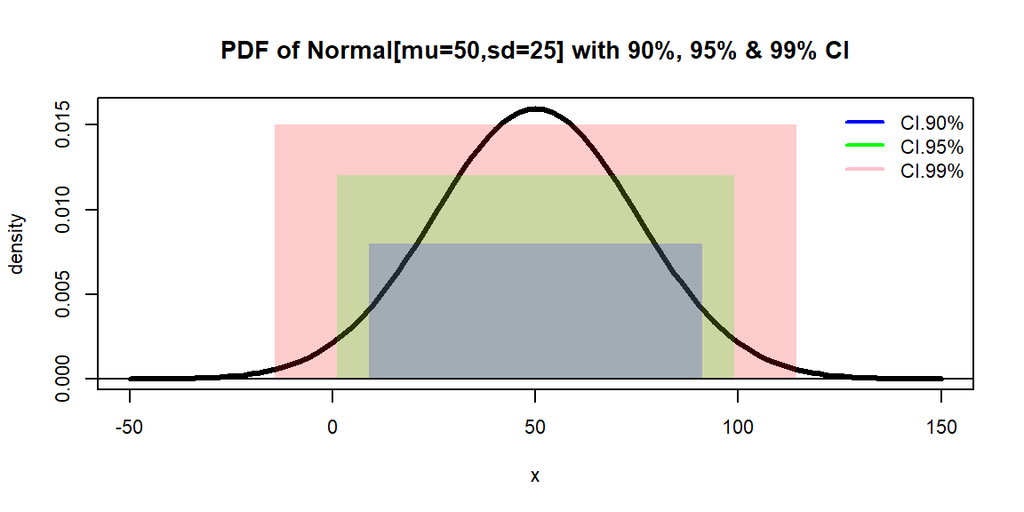

```r
par(cex=0.7)

curve(dnorm(x, 50, 25), -50, 150, lwd=3, ylab="density",
      main="PDF of Normal[mu=50,sd=25] with 90%, 95% & 99% CI")
abline(h=0)
rect(x[1],0,x[6],0.015,border=NA,col=rgb(1,0,0,0.2))
rect(x[2],0,x[5],0.012,border=NA,col=rgb(0,1,0,0.2))
rect(x[3],0,x[4],0.008,border=NA,col=rgb(0,0,1,0.2))

legend("topright",c("CI.90%","CI.95%","CI.99%"),
       col=c('blue','green','pink'),lwd=2,bty="n")
```

```r
# 左下右上
# r、g、b & 透明度
```

**🌞 **TAKE AWAYS :****

R is an integrated working environment where we can …

🌻 Draw sample data from known distribution

🌻 Generate sample data by simulating experiment and

🌻 Replicate the experiment to create distribution

🌻 Fit data into theoretic distribution or

🌻 build empirical distribution directly form data

🌻 Operate theoretical, empirical or simulated distributions in the same set of tools.

[figure not shown]